# Hitter Development Report

# Andrés Giménez

**2026 season · Profile: Under-powered · xwOBA 0.276 (5th percentile)**

Andrés Giménez squares up the ball at an average rate (44th percentile) with bat speed in the 6th percentile. Main lever: **add bat speed without giving back contact.**

## Swing profile vs MLB

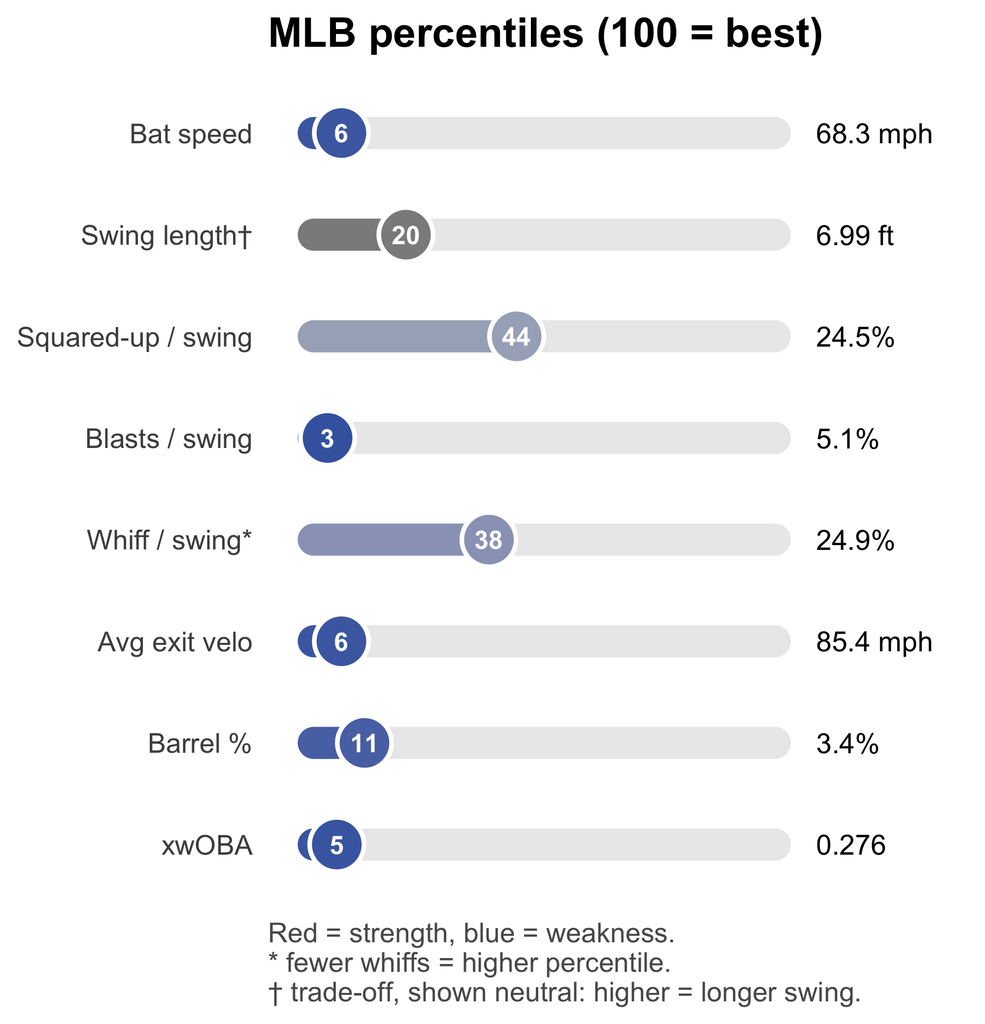

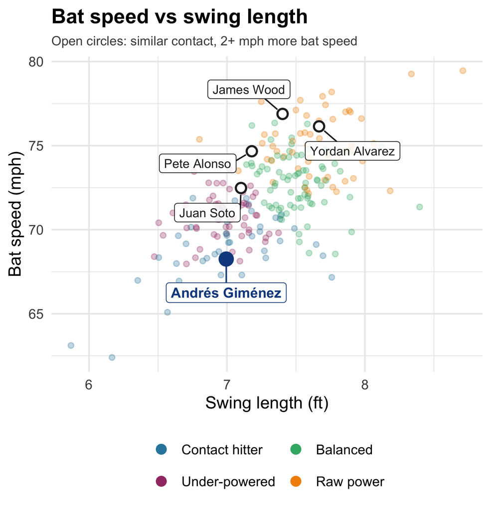

## Year-over-year

| Season | Bat speed (mph) | Swing length (ft) | Squared-up / swing | Whiff / swing | xwOBA | wOBA (actual) |
| --- | --- | --- | --- | --- | --- | --- |
| 2025 | 69.3 | 7.05 | 24.2% | 23.2% | 0.308 | 0.269 |
| 2026 | 68.3 | 6.99 | 24.5% | 24.9% | 0.276 | 0.286 |
| Change | -1.0 | -0.05 | +0.4 pts | +1.6 pts | -0.032 | +0.017 |

**From 2025 to 2026:** bat speed fell 1 mph, squared-up rate rose 0.4 pts and xwOBA fell 32 points.

## What the model says

Across 232 qualified MLB hitters in 2026, at equal swing length, contact and whiff rate, **+1 mph of bat speed is associated with +10 points of xwOBA**, and +1 point of squared-up rate with +4 points. The swing metrics explain 42% of the differences in production between hitters: the rest comes from swing decisions, timing and launch direction.

These are cross-sectional associations, not guarantees: they set the hypothesis to test with the player, not the expected outcome.

## Development plan

**Diagnosis.** Andrés Giménez’s contact is average (44th percentile in squared-up rate, 38th in whiff avoidance), but his bat speed (68.3 mph, 6th percentile) caps the damage on contact: 85.4 mph average exit velocity, 3.4% barrels.

**Priority.** Add bat speed while protecting contact quality.

1. **Screen** – Is bat speed limited by physical capacity or by sequencing? Force-plate profile (CMJ, IMTP: peak force, RFD, asymmetries) and rotational med-ball throw, read alongside the biomechanics data (kinematic sequence, lead-leg block, hip-shoulder separation).
2. **Intervene** – If capacity-limited: lower-body force and rotational power block. If sequencing-limited: intent-based swings, overload/underload bat training with the hitting coaches.
3. **Monitor** – Bat speed and squared-up rate each week (cage, BP, games). Red flag: squared-up rate dropping by more than 3 points as speed rises.

Reference points – similar contact, 2+ mph more bat speed

| Comparable hitter | Bat speed (mph) | Squared-up / swing | xwOBA |
| --- | --- | --- | --- |
| Yordan Alvarez | 76.1 | 26.7% | 0.442 |
| Juan Soto | 72.5 | 34.8% | 0.411 |
| James Wood | 76.9 | 25.4% | 0.403 |
| Pete Alonso | 74.7 | 25.1% | 0.402 |

Data: Baseball Savant, public Statcast data (bat tracking, expected stats, exit velocity). Bat speed = average of the top 90% of competitive swings. Percentiles (1–100), model and profiles are based on the 232 qualified MLB hitters in 2026 (570+ competitive swings). Profiles: k-means on bat speed, swing length, squared-up and whiff rates. Internal biomechanics data would replace the screening hypotheses with measured values. Report: Hugo Leligny.